# Reproducible Research: Peer Assessment 1

## Introduction

This is the first project of Reproducible Research course in Data Science Specialization. This file consists of answers to the questions asked in the Reproducible Research Course Project 1.

### Sourcing necessary packages

```r
library(knitr)
opts_chunk$set(echo = TRUE)
library(dplyr)
library(lubridate)
library(lattice)
```

## Loading and preprocessing the data

Below code checks if the file already exists, if not then it downloads the file, unzips it and reads the datafile. 1. Load the data

```r
if (!file.exists("./UCI HAR Dataset")) {
    url <- "https://d396qusza40orc.cloudfront.net/repdata%2Fdata%2Factivity.zip"
    download.file(url, "Dataset.zip")
    unzip("Dataset.zip")
}

data <- read.table("activity.csv", header = TRUE, sep = ",", stringsAsFactors = TRUE)
```

2. Process/transform the data (if necessary) into a format suitable for your analysis ### Formats the date to YYYY-MM-DD format.

```r
data$date <- ymd(data$date)
```

## What is mean total number of steps taken per day?

Ignoring the missing values, i.e. NAs in the data. 1. Calculating the total number of steps taken per day.

```r
steps_a_day <- data %>%
                  filter(!is.na(steps)) %>%
                  group_by(date) %>%
                  summarize(steps = sum(steps))
```

2. Making a histogram of the total number of steps taken each day.

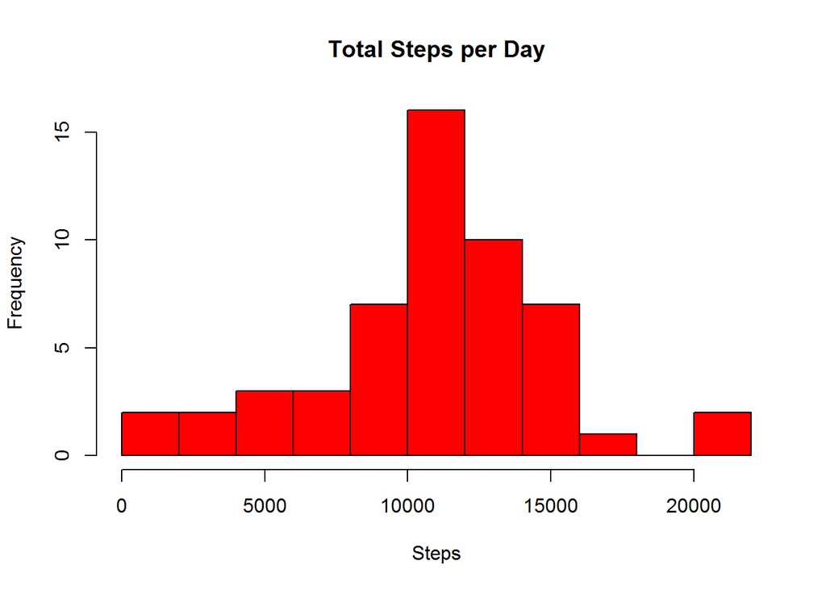

```r
hist(steps_a_day$steps, breaks = 10, xlab = "Steps", ylab = "Frequency", main = "Total Steps per Day", col = "red")
```

3. Calculating and reporting the mean and median of the total number of steps taken per day.
1. Mean of total number of steps taken per day is:

```r
mean_step <- mean(steps_a_day$steps, na.rm = TRUE)
print(paste("Mean of total number of steps taken per day is: ", mean_step))
```

```
## [1] "Mean of total number of steps taken per day is:  10766.1886792453"
```

2. Median of total number of steps taken per day is:

```r
median_step <- median(steps_a_day$steps, na.rm = TRUE)
print(paste("Median of total number of steps taken per day is: ", median_step))
```

```
## [1] "Median of total number of steps taken per day is:  10765"
```

## What is the average daily activity pattern?

1. Make a time series plot (i.e. type = “l”) of the 5-minute interval (x-axis) and the average number of steps taken, averaged across all days (y-axis)

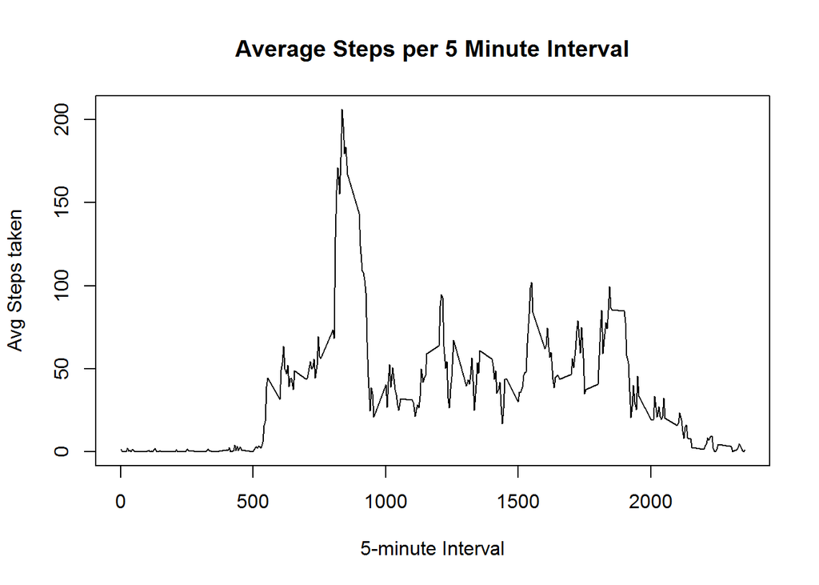

```r
avg_step <- aggregate(steps ~ interval, data = data, mean, na.rm = TRUE)

plot(avg_step$interval, avg_step$steps, type="l", main="Average Steps per 5 Minute Interval", xlab="5-minute Interval", ylab="Avg Steps taken")
```

2. Which 5-minute interval, on average across all the days in the dataset, contains the maximum number of steps?

```r
max_steps <- avg_step[which.max(avg_step$steps),]
print(paste("Maximum number of steps in a 5-minute interval is: ", max_steps[1,2]))
```

```
## [1] "Maximum number of steps in a 5-minute interval is:  206.169811320755"
```

```r
print(paste("And the particular 5-minute interval is: ", max_steps[1,1]))
```

```
## [1] "And the particular 5-minute interval is:  835"
```